Skip to main content

# FaceZonGoogAppFlix Webpage Redesign

Executive Summary: A/B Test Results & Strategic Recommendations

Author

Data Science Consulting Team

Published

November 19, 2026

## Headline Recommendations

**ImportantExecutive Decision & Strategic Guidance**

1. **Do Not Launch `new_page` — Retain `old_page`:** Across **`290,584`** valid unique visitors over 22 days, the redesigned page converted at **`11.88%`** versus **`12.04%`** for the existing page—an observed **`-1.31%` relative change** (95% CI: **`[-3.26%, +0.64%]`**, $p = 0.19$). There is **no statistical evidence** of a conversion lift, and the best estimate trends slightly negative. Keeping `old_page` avoids engineering rollout risk for no demonstrated return.
2. **Right-Size Future Experiment Targets Before Testing:** FaceZonGoogAppFlix’s goal of a **`+0.35%` relative lift** (`12.00%` → `12.042%`) is too small to measure reliably at current traffic—achieving standard `80%` statistical power would require **`~18.8 million` users (`~3.9 years`)**. For a practical 3-week experiment (`~290k` users), future redesigns should focus on bolder changes targeting **`~2.8%+` relative lift**, or incorporate variance-reduction methods (e.g., CUPED).

### Results at a Glance

|  | Metric | Result |
| --- | --- | --- |
| 0 | Clean Sample Size (22-Day Test) | 290,584 unique users (145,274 control / 145,31... |
| 1 | Control (`old_page`) Conversion Rate | 12.04% (17,489 conversions) |
| 2 | Treatment (`new_page`) Conversion Rate | 11.88% (17,264 conversions) |
| 3 | Observed Relative Lift | -1.31% (-0.16 percentage points) |
| 4 | 95% Confidence Interval (Relative Lift) | [-3.26%, +0.64%] |
| 5 | Two-Sided p-Value (α = 0.05) | 0.1899 (not statistically significant) |
| 6 | Achieved Power for +0.35% Relative Target | 6.4% (vs. 80% standard benchmark) |
| 7 | Launch Decision | Retain old_page (Do Not Ship new_page) |

## Recommendation 1 Evidence: No Demonstrated Conversion Lift

- **Observed direction is negative:** `new_page` trailed `old_page` by **`-1.31%` relative** (`-0.16` percentage points).
- **Confidence interval spans zero:** The 95% confidence interval (`-3.26%` to `+0.64%` relative) comfortably includes `0%`, confirming the observed difference is indistinguishable from random chance ($p = 0.19$).
- **Nuance on the upper bound:** Because the test lacked statistical power for a `+0.35%` relative target, the upper edge of the 95% CI (`+0.64%`) does not strictly rule out `+0.35%`—however, with a negative point estimate and zero evidence of uplift, launching `new_page` is not supported.

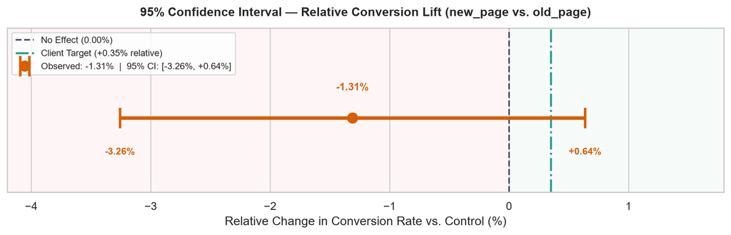

95% confidence interval for the relative conversion lift of new_page vs. old_page. The interval crosses 0% (no statistically significant effect) and centers at -1.31%.

## Recommendation 2 Evidence: Why Future Targets Must Be Right-Sized

- **Severe underpowering at `+0.35%` relative lift:** A `+0.35%` relative gain on a `12.00%` baseline equals just **`+0.042` percentage points** (`4.2` extra conversions per `10,000` visitors). With `~145,292` users per arm, this test had only **`6.4%` statistical power** to detect a gain that small—barely above the `5%` false-positive rate.
- **Practical sizing for future tests:** To reach the standard **`80%` power** benchmark within a 3-week test window (`~290k` users), future page changes need to target at least a **`+2.81%` relative lift** (`12.00%` → `12.34%`).

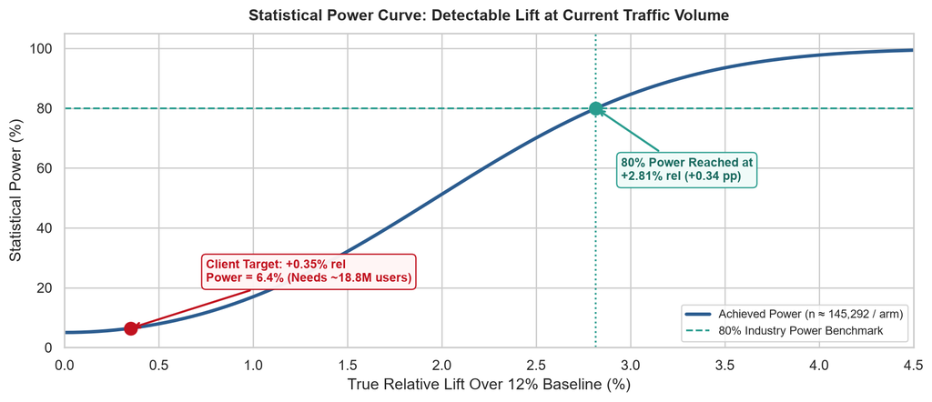

Statistical power curve for the current sample size (~145,292 users/arm, α = 0.05 two-sided). Achieving 80% power requires roughly a +2.81% relative lift; the +0.35% relative target had only 6.4% power.

### Planning Guide for Future Experiments (80% Power, $\alpha = 0.05$)

|  | Target Scenario | Target Rate | Required Total Users | Est. Runtime (~13.2k users/day) |
| --- | --- | --- | --- | --- |
| 0 | Current Target (+0.35% relative) | 12.042% | 18,822,992 | ~3.9 years |
| 1 | Moderate Target (+1.00% relative) | 12.120% | 2,312,270 | ~5.8 months |
| 2 | Current 3-Week Capacity (+2.81% relative) | 12.338% | 294,106 | ~22 days |

## Immediate Next Steps

1. **Keep `old_page` in production** and archive the `new_page` variant rather than shipping an unproven redesign.
2. **Adopt pre-test power sizing** using the planning table above—focus design iterations on higher-impact changes (`~2.8%+` relative lift for 3-week tests) or apply variance reduction (e.g., CUPED) when evaluating smaller UX tweaks.
3. **Resolve the `1.32%` assignment/page logging discrepancy** (`3,893` misaligned records identified during data exploration) with engineering before launching the next A/B test so future telemetry is clean out of the box.

*Supporting technical reports: Phase 1 Initial Data Exploration (`01_initial_data_exploration.html`) and Phase 2 Step-by-Step Statistical Analysis (`02_ab_test_analysis.html`).*